# R Notebook

# Box Plots

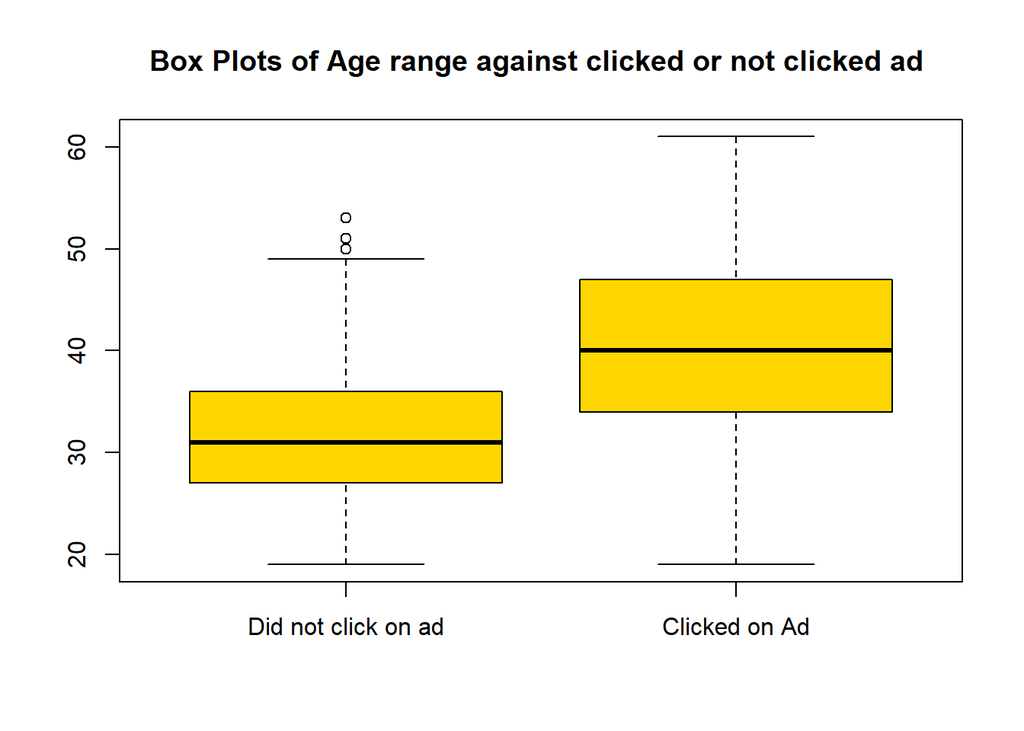

```r
x3 <- addf$Age[addf$`Clicked on Ad`==0]
x4 <- addf$Age[addf$`Clicked on Ad`==1]
boxplot(x3, x4,names=c("Did not click on ad","Clicked on Ad"),
        col="gold")
title("Box Plots of Age range against clicked or not clicked ad ")
```

Outliers are present in the ‘did not click on ad’ category

# Summary of outliers of the ages of those who did not click on ad.

```r
boxplot.stats(x3)$out
```

```
## [1] 53 51 51 50
```

# Mininimum age that accessed the ad

```r
minAge <- min(addf$Age)
minAge
```

```
## [1] 19
```

# Maximum age

```r
maxAge <- max(addf$Age)
maxAge
```

```
## [1] 61
```

The youngest person that accessed the ad was 19yrs with the oldest being 61yrs

# Mean of Daily Internet Usage

```r
mean_addf <- mean(addf$`Daily Internet Usage`)
mean_addf
```

```
## [1] 180.0001
```

# Mean of time spent on the site

```r
mean_addf1<- mean(addf$`Daily Time Spent on Site`)
mean_addf1
```

```
## [1] 65.0002
```

The mean amount of min of daily internet usage is 180 while the mean of the daily time spent on the site is 65 min

# Quartiles of Internet usage

```r
addf_InternetUsage_quantile <- quantile(addf$`Daily Internet Usage`)
addf_InternetUsage_quantile
```

```
##       0%      25%      50%      75%     100%
## 104.7800 138.8300 183.1300 218.7925 269.9600
```

# Quartiles of Time spent on a site

```r
addf_TimeSpent_quantile <- quantile(addf$`Daily Time Spent on Site`)
addf_TimeSpent_quantile
```

```
##      0%     25%     50%     75%    100%
## 32.6000 51.3600 68.2150 78.5475 91.4300
```

# Standard deviation of Time spent on a site

```r
addf_TimeSpent_sd <- sd(addf$`Daily Time Spent on Site`)
addf_TimeSpent_sd
```

```
## [1] 15.85361
```

# Standard deviation of Internet usage

```r
addf_InternetUsage_sd <- sd(addf$`Daily Internet Usage`)
addf_InternetUsage_sd
```

```
## [1] 43.90234
```

# Histogram

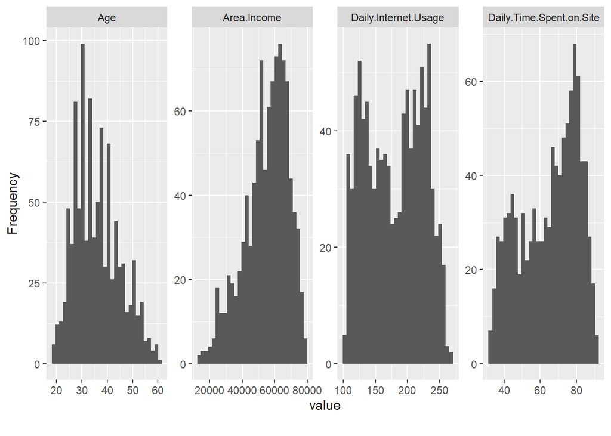

```r
plot_histogram(addf)
```

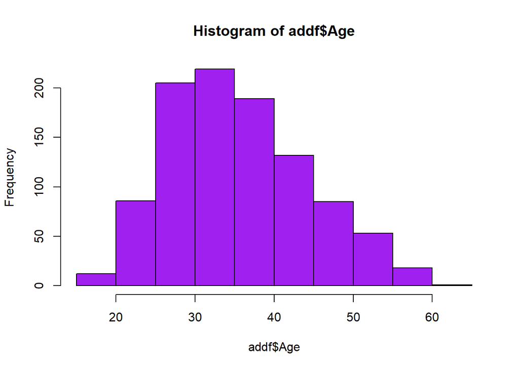

```r
hist(addf$Age,col="purple")
```

Most people involved in this study were between the age of 30-40 yrs

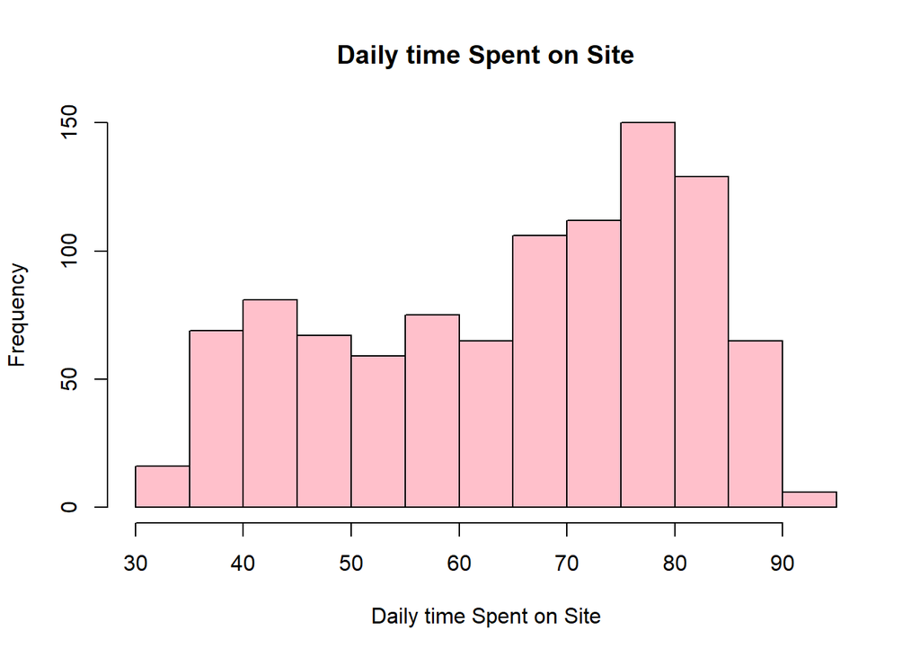

```r
timespent_hist= hist(addf$`Daily Time Spent on Site`,
                     main = "Daily time Spent on Site",
                     xlab = "Daily time Spent on Site",
                     col = "pink"
)
```

From this plot,we can see that most people spent approx 75-80 mins on the site

# Frequency

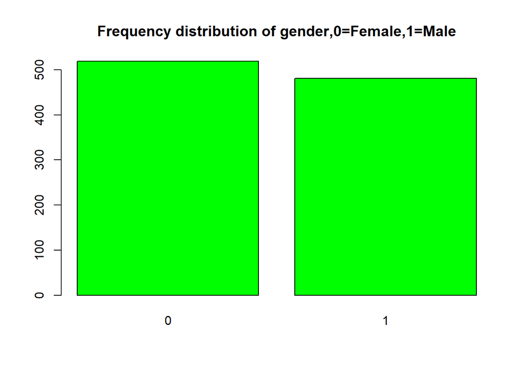

```r
gender <- addf$Male
gender_freq <- table(gender)
barplot(gender_freq,
        col = "green")
title("Frequency distribution of gender,0=Female,1=Male")
```

More females were involved in this study than males

# Comparison by gender on number of clicks

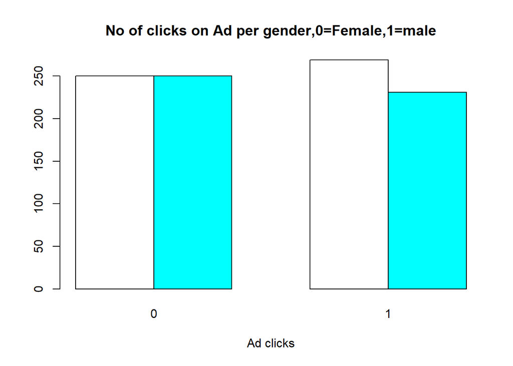

```r
clicks = table(addf$Male,addf$`Clicked on Ad`)
barplot(clicks,main="No of clicks on Ad per gender,0=Female,1=male",xlab="Ad clicks",col=c("white","cyan"),beside=TRUE)
```

```r
legends = rownames(clicks)
```

Females tend to click on ads more than men.

# Comparison by age on number of clicks

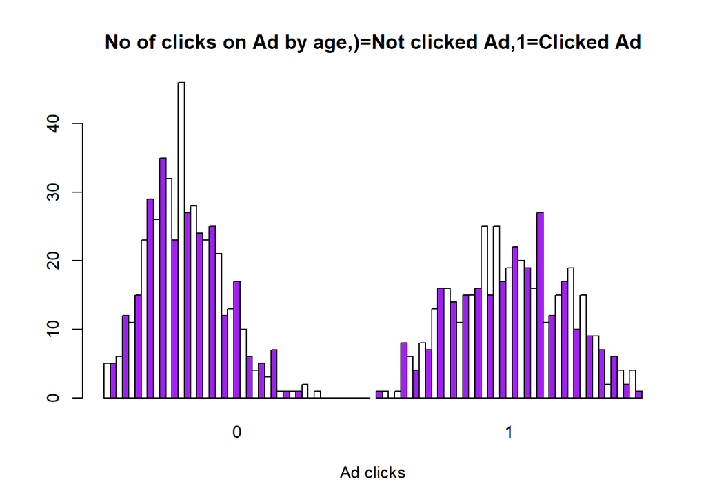

```r
clicks1 = table(addf$Age,addf$`Clicked on Ad`)
barplot(clicks1,main="No of clicks on Ad by age,)=Not clicked Ad,1=Clicked Ad",xlab="Ad clicks",col=c("white","purple"),beside = TRUE)
```

```r
legends = rownames(clicks1)
```

The group that clicked on the ads more frequently were between the age of 36 to 47 yrs

# Bivariate analysis

## Corelation

Correlation is a normalized measurement of how the two are linearly related

```r
timespent_c <- addf$`Daily Time Spent on Site`
internetusage_c <- addf$`Daily Internet Usage`

cor(timespent_c,internetusage_c)
```

```
## [1] 0.5186585
```

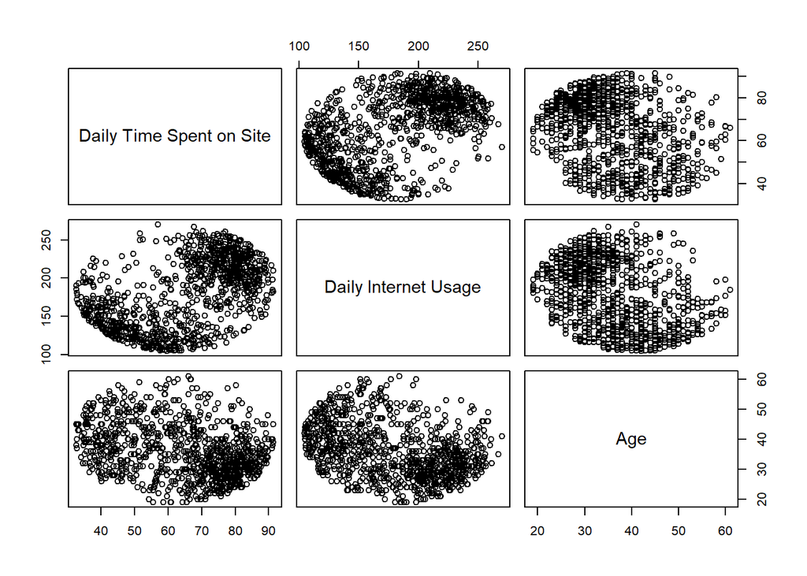

```r
pairs(data=addf,
      ~`Daily Time Spent on Site`+ `Daily Internet Usage` + Age)
```

# Correlation matrix

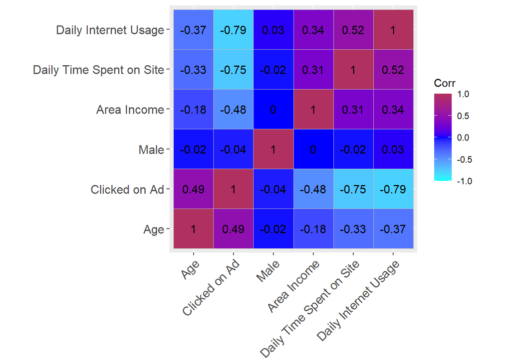

```r
library(ggcorrplot)
corr = round(cor(select_if(addf, is.numeric)), 4)
ggcorrplot(corr, hc.order = T, ggtheme = ggplot2::theme_grey,
           colors = c("cyan", "blue", "maroon"), lab = T)
```

## Covariance Covariance is a number that reflects the degree to which two variable vary together

```r
cov(timespent_c,internetusage_c)
```

```
## [1] 360.9919
```

## Scatterplots

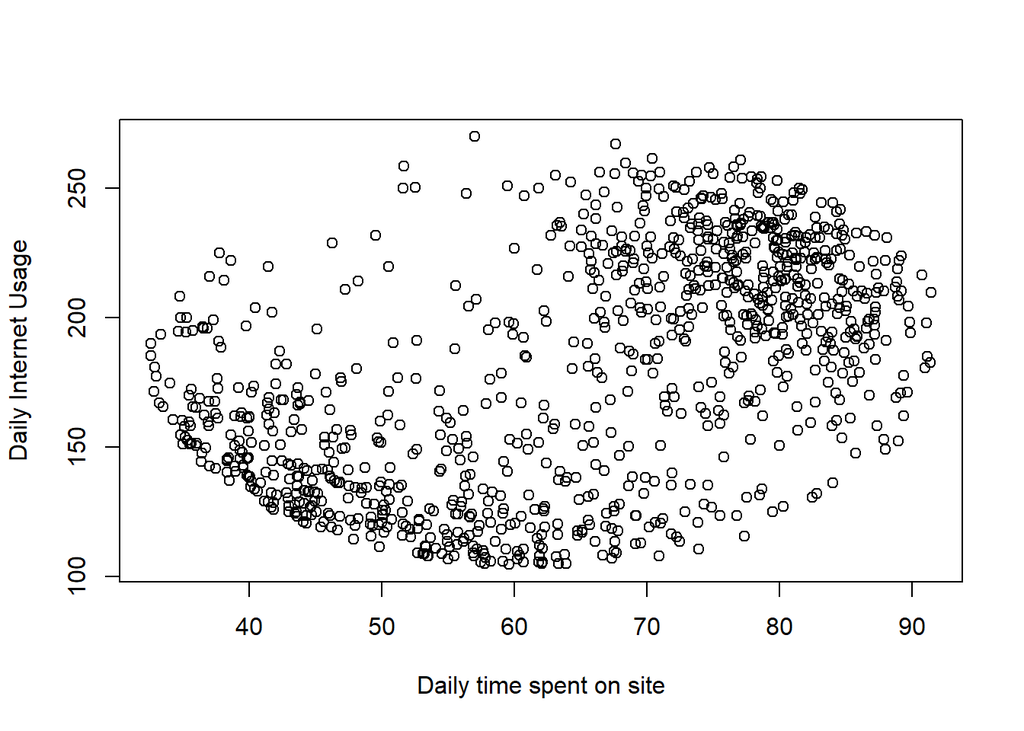

```r
plot(timespent_c,internetusage_c, xlab="Daily time spent on site", ylab="Daily Internet Usage")
```